# Factors Associated with Laboratory Confirmation of Ebola Virus Disease Among Suspected Cases in Sierra-Leone, West Africa:

Ojiambo Ivan

2026-07-05

Loading Libraries—-

`Loading study Ebola data—

**CLEANING EBOLA_DATA—-**

clean column

```
## [1] "id"             "age"            "sex"            "status"
## [5] "date_of_onset"  "date_of_sample" "district"
```

**Checking of missing data–**

```
##             id            age            sex         status  date_of_onset
##              0              4              0              0              0
## date_of_sample       district
##              0              0
```

```
##             id            age            sex         status  date_of_onset
##              0              2              0              0              0
## date_of_sample       district
##              0              0
```

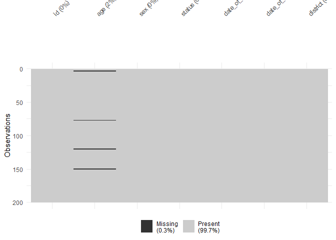

**checking Duplicates—**

```
## [1] 0
```

**cleaning_age—-**

```
##    Min. 1st Qu.  Median    Mean 3rd Qu.    Max.     NAs
##    1.80   20.00   35.00   33.85   45.00   80.00       4
```

```
##    Min. 1st Qu.  Median    Mean 3rd Qu.    Max.
##    1.80   20.00   35.00   33.85   45.00   80.00
```

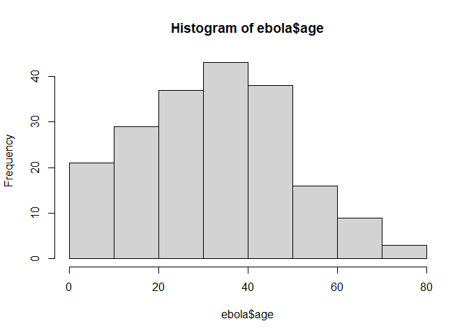

**cleaning_sex—**

[output not shown]

**cleaning_status—-**

```
## [1] "confirmed" "suspected"
```

**cleaning_districts—-**

```
## [1] "Kailahun"      "Kenema"        "Kono"          "Bo"
## [5] "Western Urban" "Kambia"        "Port Loko"
```

**dates_cleaning—**

*date of onset*

```
## [1] "2014-06-10" "2014-05-30" "2014-06-13" "2014-05-22" "2014-06-24"
## [6] "2014-06-19"
```

*date of the sample*

```
## [1] "2014-06-15" "2014-06-04" "2014-06-18" "2014-05-27" "2014-06-29"
## [6] "2014-06-24"
```

**sample data before onset data—**

```
## # A tibble: 0 × 7
## # ℹ 7 variables: id <dbl>, age <dbl>, sex <fct>, status <fct>,
## #   date_of_onset <date>, date_of_sample <date>, district <fct>
```

**delay variables—**

[output not shown]

[output cut: 186 more lines]

```
##  ebola$delay_days
##  Min.   : 0.000
##  1st Qu.: 5.000
##  Median : 5.000
##  Mean   : 5.617
##  3rd Qu.: 5.000
##  Max.   :22.000
```

**Creating Age_group—**

```
## [1] 1.8
```

```
## [1] 80
```

The minimum age was **1.8** and maximum age was **80**

**structure check—**

```
## spc_tbl_ [196 × 9] (S3: spec_tbl_df/tbl_df/tbl/data.frame)
##  $ id            : num [1:196] 92 51 139 8 215 189 115 218 159 119 ...
##  $ age           : num [1:196] 6 46 25 8 49 13 50 35 38 60 ...
##  $ sex           : Factor w/ 2 levels "female","male": 2 1 1 1 2 1 2 1 1 1 ...
##  $ status        : Factor w/ 2 levels "suspected","confirmed": 2 2 2 2 2 2 2 2 2 2 ...
##  $ date_of_onset : Date[1:196], format: "2014-06-10" "2014-05-30" ...
##  $ date_of_sample: Date[1:196], format: "2014-06-15" "2014-06-04" ...
##  $ district      : Factor w/ 7 levels "bo","kailahun",..: 2 2 2 2 2 2 2 4 2 2 ...
##  $ delay_days    :'data.frame':  196 obs. of  1 variable:
##   ..$ ebola$delay_days: num [1:196] 5 5 5 5 5 5 15 3 8 5 ...
##  $ age_group     : Factor w/ 5 levels "0-14","15-24",..: 1 5 3 1 5 1 5 4 4 5 ...
##  - attr(*, "spec")=
##   .. cols(
##   ..   id = col_double(),
##   ..   age = col_double(),
##   ..   sex = col_character(),
##   ..   status = col_character(),
##   ..   date_of_onset = col_date(format = ""),
##   ..   date_of_sample = col_date(format = ""),
##   ..   district = col_character()
##   .. )
##  - attr(*, "problems")=<pointer: 0x000002393fdfb0d0>
```

| Var1 | Var2 | Freq |
| --- | --- | --- |
|  | id | Min. : 1.0 |
|  | id | 1st Qu.: 64.5 |
|  | id | Median :131.5 |
|  | id | Mean :136.9 |
|  | id | 3rd Qu.:208.2 |
|  | id | Max. :285.0 |
|  | id | NA |
|  | age | Min. : 1.80 |
|  | age | 1st Qu.:20.00 |
|  | age | Median :35.00 |

[output cut: 53 more lines]

**ANALYSIS OF FACTORS ASSOCIATED WITH CONFIRMED EBOLA—-**

**Descriptive analysis**

```
## spc_tbl_ [196 × 9] (S3: spec_tbl_df/tbl_df/tbl/data.frame)
##  $ id            : num [1:196] 92 51 139 8 215 189 115 218 159 119 ...
##  $ age           : num [1:196] 6 46 25 8 49 13 50 35 38 60 ...
##  $ sex           : chr [1:196] "male" "female" "female" "female" ...
##  $ status        : chr [1:196] "confirmed" "confirmed" "confirmed" "confirmed" ...
##  $ date_of_onset : Date[1:196], format: "2014-06-10" "2014-05-30" ...
##  $ date_of_sample: Date[1:196], format: "2014-06-15" "2014-06-04" ...
##  $ district      : chr [1:196] "kailahun" "kailahun" "kailahun" "kailahun" ...
##  $ delay_days    : num [1:196] 5 5 5 5 5 5 15 3 8 5 ...
##  $ age_group     : chr [1:196] "0-14" "45+" "25-34" "0-14" ...
##  - attr(*, "spec")=
##   .. cols(
##   ..   id = col_double(),
##   ..   age = col_double(),
##   ..   sex = col_character(),
##   ..   status = col_character(),
##   ..   date_of_onset = col_date(format = ""),
##   ..   date_of_sample = col_date(format = ""),
##   ..   district = col_character(),
##   ..   delay_days = col_double(),
##   ..   age_group = col_character()
##   .. )
##  - attr(*, "problems")=<pointer: 0x000002393fdfd910>
```

| Var1 | Var2 | Freq |
| --- | --- | --- |
|  | id | Min. : 1.0 |
|  | id | 1st Qu.: 64.5 |
|  | id | Median :131.5 |
|  | id | Mean :136.9 |
|  | id | 3rd Qu.:208.2 |
|  | id | Max. :285.0 |
|  | age | Min. : 1.80 |
|  | age | 1st Qu.:20.00 |
|  | age | Median :35.00 |
|  | age | Mean :33.85 |

[output cut: 44 more lines]

**Total number of cases after cleaning–**

```
## [1] 196
```

**frquency destribution of status—**

```
##
## confirmed suspected
##       179        17
```

**percentage of status–**

| Var1 | Freq |
| --- | --- |
| confirmed | 91.3265306122449 |
| suspected | 8.6734693877551 |

**frequency_destribution of sex—**

| Var1 | Freq |
| --- | --- |
| female | 57.1428571428571 |
| male | 42.8571428571429 |

**Cross_tabulation of Sex Vs Status—**

```
##
##          confirmed suspected
##   female       100        12
##   male          79         5
```

| Var1 | Var2 | Freq |
| --- | --- | --- |
| female | confirmed | 89.2857142857143 |
| male | confirmed | 94.0476190476191 |
| female | suspected | 10.7142857142857 |
| male | suspected | 5.95238095238095 |

**Descriptive statistics for Age–**

```
## # A tibble: 1 × 4
##    Mean    SD Meadian   IQR
##   <dbl> <dbl>   <dbl> <dbl>
## 1  33.8  17.3      35    25
```

**Age_group–**

```
##
##  0-14 15-24 25-34 35-44   45+
##    31    26    37    48    54
```

```
##
##     0-14    15-24    25-34    35-44      45+
## 15.81633 13.26531 18.87755 24.48980 27.55102
```

**Age Group Vs status—**

```
##
##         confirmed suspected
##   0-14         29         2
##   15-24        24         2
##   25-34        32         5
##   35-44        42         6
##   45+          52         2
```

```
##
##         confirmed suspected
##   0-14  93.548387  6.451613
##   15-24 92.307692  7.692308
##   25-34 86.486486 13.513514
##   35-44 87.500000 12.500000
##   45+   96.296296  3.703704
```

**District destribution–**

```
##
##            bo      kailahun        kambia        kenema          kono
##             2           152             1            33             2
##     port loko western urban
##             2             4
```

```
##
##      kailahun        kenema western urban            bo          kono
##           152            33             4             2             2
##     port loko        kambia
##             2             1
```

**District Vs Status—**

| Var1 | Var2 | Freq |
| --- | --- | --- |
| bo | confirmed | 2 |
| kailahun | confirmed | 141 |
| kambia | confirmed | 1 |
| kenema | confirmed | 31 |
| kono | confirmed | 2 |
| port loko | confirmed | 2 |
| western urban | confirmed | 0 |
| bo | suspected | 0 |
| kailahun | suspected | 11 |
| kambia | suspected | 0 |

[output cut: 4 more lines]

**Delay Days Summary—**

```
##    Min. 1st Qu.  Median    Mean 3rd Qu.    Max.
##   0.000   5.000   5.000   5.617   5.000  22.000
```

```
## [1] 5.617347
```

```
## [1] 5
```

**Epidermiological Week**

| epi_week | cases |
| --- | --- |
| 20 | 1 |
| 21 | 12 |
| 22 | 35 |
| 23 | 16 |
| 24 | 57 |
| 25 | 25 |
| 26 | 50 |

**Epidemic curve–**

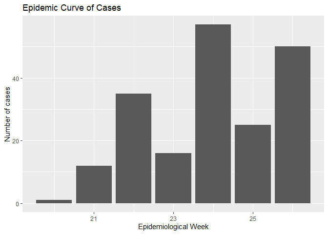

**Epidemic curve by status–**

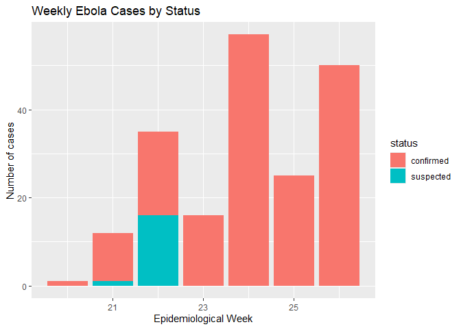

**Bar-chart of sex Distribution—**

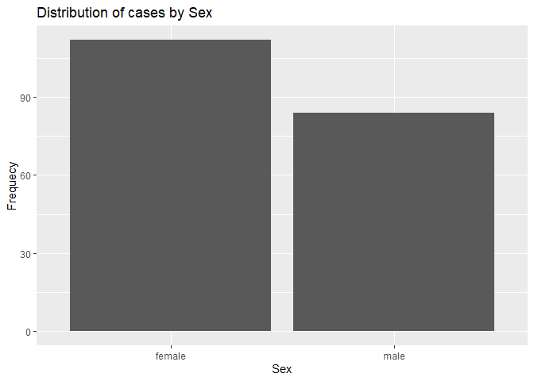

**Bar_chart of Age distribution**

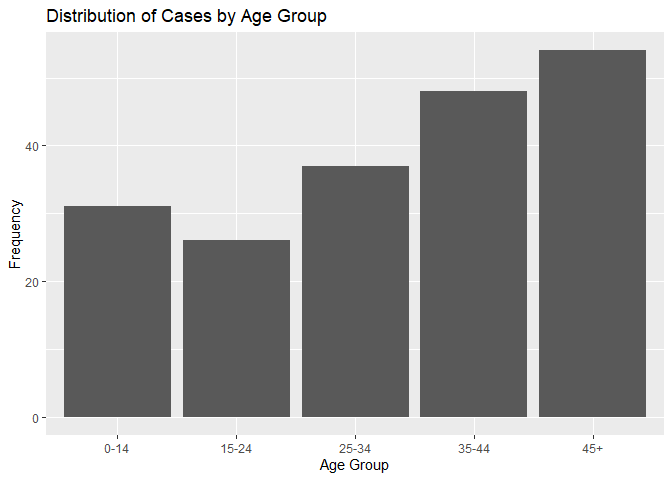

**Boxplot of Age by status**

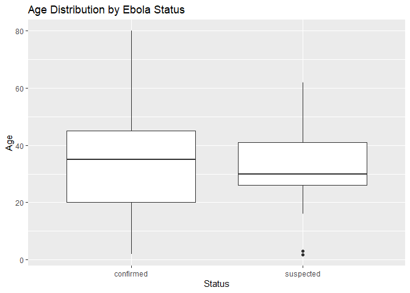

**Frequency Tables with percentages Together–**

| sex | n | percent |
| --- | --- | --- |
| female | 112 | 57.1 |
| male | 84 | 42.9 |

**Status Proportion by District—**

| district | status | n | percent |
| --- | --- | --- | --- |
| bo | confirmed | 2 | 100 |
| kailahun | confirmed | 141 | 92.8 |
| kailahun | suspected | 11 | 7.2 |
| kambia | confirmed | 1 | 100 |
| kenema | confirmed | 31 | 93.9 |
| kenema | suspected | 2 | 6.1 |
| kono | confirmed | 2 | 100 |
| port loko | confirmed | 2 | 100 |
| western urban | suspected | 4 | 100 |

**Chi-Square Analysis—-**

**chi-square test: Sex Vs Status**

| Var1 | Var2 | Freq |
| --- | --- | --- |
| female | confirmed | 100 |
| male | confirmed | 79 |
| female | suspected | 12 |
| male | suspected | 5 |

```
##
##  Pearson's Chi-squared test with Yates' continuity correction
##
## data:  sex_status
## X-squared = 0.83867, df = 1, p-value = 0.3598
```

| Var1 | Var2 | Freq |
| --- | --- | --- |
| female | confirmed | 89.2857142857143 |
| male | confirmed | 94.0476190476191 |
| female | suspected | 10.7142857142857 |
| male | suspected | 5.95238095238095 |

**chi-square test:Age_group Vs status**

| Var1 | Var2 | Freq |
| --- | --- | --- |
| 0-14 | confirmed | 29 |
| 15-24 | confirmed | 24 |
| 25-34 | confirmed | 32 |
| 35-44 | confirmed | 42 |
| 45+ | confirmed | 52 |
| 0-14 | suspected | 2 |
| 15-24 | suspected | 2 |
| 25-34 | suspected | 5 |
| 35-44 | suspected | 6 |
| 45+ | suspected | 2 |

```
##
##  Pearson's Chi-squared test
##
## data:  age_status
## X-squared = 3.8901, df = 4, p-value = 0.4211
```

```
##
##  Fisher's Exact Test for Count Data
##
## data:  age_status
## p-value = 0.4071
## alternative hypothesis: two.sided
```

| Var1 | Var2 | Freq |
| --- | --- | --- |
| 0-14 | confirmed | 93.5483870967742 |
| 15-24 | confirmed | 92.3076923076923 |
| 25-34 | confirmed | 86.4864864864865 |
| 35-44 | confirmed | 87.5 |
| 45+ | confirmed | 96.2962962962963 |
| 0-14 | suspected | 6.45161290322581 |
| 15-24 | suspected | 7.69230769230769 |
| 25-34 | suspected | 13.5135135135135 |
| 35-44 | suspected | 12.5 |
| 45+ | suspected | 3.7037037037037 |

**chi-square test:Districts Vs Status**

| Var1 | Var2 | Freq |
| --- | --- | --- |
| kailahun | confirmed | 141 |
| kenema | confirmed | 31 |
| other District | confirmed | 7 |
| kailahun | suspected | 11 |
| kenema | suspected | 2 |
| other District | suspected | 4 |

```
##
##  Pearson's Chi-squared test
##
## data:  district_status
## X-squared = 11.328, df = 2, p-value = 0.003468
```

|  | confirmed | suspected |
| --- | --- | --- |
| kailahun | 138.816326530612 | 13.1836734693878 |
| kenema | 30.1377551020408 | 2.86224489795918 |
| other District | 10.0459183673469 | 0.954081632653061 |

```
##
##  Fisher's Exact Test for Count Data
##
## data:  district_status
## p-value = 0.01328
## alternative hypothesis: two.sided
```

**Chi-Square Test workflow**

**Sex**

```
##
##  Pearson's Chi-squared test with Yates' continuity correction
##
## data:  table(cleaned_ebola$sex, cleaned_ebola$status)
## X-squared = 0.83867, df = 1, p-value = 0.3598
```

**Age_group**

```
##
##  Pearson's Chi-squared test
##
## data:  table(cleaned_ebola$age_group, cleaned_ebola$status)
## X-squared = 3.8901, df = 4, p-value = 0.4211
```

```
##
##  Fisher's Exact Test for Count Data
##
## data:  table(cleaned_ebola$age_group, cleaned_ebola$status)
## p-value = 0.4071
## alternative hypothesis: two.sided
```

**District**

```
##
##  Pearson's Chi-squared test
##
## data:  table(cleaned_ebola$district, cleaned_ebola$status)
## X-squared = 43.463, df = 6, p-value = 9.445e-08
```

```
##
##  Fisher's Exact Test for Count Data
##
## data:  table(cleaned_ebola$district, cleaned_ebola$status)
## p-value = 0.001161
## alternative hypothesis: two.sided
```

**summary of sex table**

| sex | status | n | percent |
| --- | --- | --- | --- |
| female | confirmed | 100 | 89.3 |
| female | suspected | 12 | 10.7 |
| male | confirmed | 79 | 94 |
| male | suspected | 5 | 6 |

**Visualization of association—-**

**stacked bar-chart**

*sex Vs status*

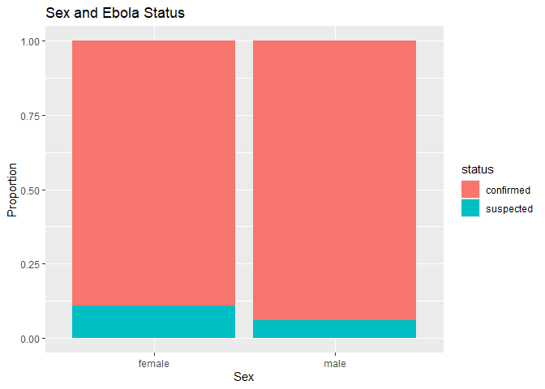

**Age group Vs status**

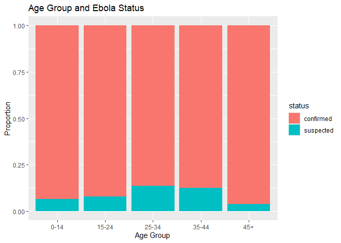

**Binary Logistic Regression—-**

```
##  chr [1:196] "confirmed" "confirmed" "confirmed" "confirmed" "confirmed" ...
```

```
## [1] "suspected" "confirmed"
```

```
##  Factor w/ 2 levels "suspected","confirmed": 2 2 2 2 2 2 2 2 2 2 ...
```

**Reference category checking**

```
## [1] "female" "male"
```

```
## [1] "0-14"  "15-24" "25-34" "35-44" "45+"
```

```
## [1] "kailahun"       "kenema"         "other District"
```

**Setting of reference category**

**Crude Logistic Regression—**

**sex only**

```
##
## Call:
## glm(formula = status ~ sex, family = binomial, data = cleaned_ebola)
##
## Coefficients:
##             Estimate Std. Error z value Pr(>|z|)
## (Intercept)   2.1203     0.3055   6.940 3.92e-12 ***
## sexmale       0.6397     0.5532   1.157    0.247
## ---
## Signif. codes:  0 '***' 0.001 '**' 0.01 '*' 0.05 '.' 0.1 ' ' 1
##
## (Dispersion parameter for binomial family taken to be 1)
##
##     Null deviance: 115.61  on 195  degrees of freedom
## Residual deviance: 114.18  on 194  degrees of freedom
## AIC: 118.18
##
## Number of Fisher Scoring iterations: 5
```

```
## (Intercept)     sexmale
##    8.333333    1.896000
```

|  | 2.5 % | 97.5 % |
| --- | --- | --- |
| (Intercept) | 4.77540283406285 | 15.9884282720257 |
| sexmale | 0.672743288289034 | 6.16380275429902 |

**logistic regression for Age Group**

```
##
## Call:
## glm(formula = status ~ age_group, family = binomial, data = cleaned_ebola)
##
## Coefficients:
##                Estimate Std. Error z value Pr(>|z|)
## (Intercept)      2.6741     0.7311   3.658 0.000254 ***
## age_group15-24  -0.1892     1.0374  -0.182 0.855250
## age_group25-34  -0.8179     0.8751  -0.935 0.349984
## age_group35-44  -0.7282     0.8514  -0.855 0.392387
## age_group45+     0.5839     1.0265   0.569 0.569445
## ---
## Signif. codes:  0 '***' 0.001 '**' 0.01 '*' 0.05 '.' 0.1 ' ' 1
##
## (Dispersion parameter for binomial family taken to be 1)
##
##     Null deviance: 115.61  on 195  degrees of freedom
## Residual deviance: 111.52  on 191  degrees of freedom
## AIC: 121.52
##
## Number of Fisher Scoring iterations: 6
```

```
##    (Intercept) age_group15-24 age_group25-34 age_group35-44   age_group45+
##     14.5000000      0.8275862      0.4413793      0.4827586      1.7931034
```

|  | 2.5 % | 97.5 % |
| --- | --- | --- |
| (Intercept) | 4.37321102069633 | 89.722498102295 |
| age_group15-24 | 0.0935486475267073 | 7.31809476591787 |
| age_group25-34 | 0.0599605952326955 | 2.22257360376367 |
| age_group35-44 | 0.0674809298607046 | 2.26572684643913 |
| age_group45+ | 0.206360844803927 | 15.5909053068426 |

**logistic for District**

```
##
## Call:
## glm(formula = status ~ district, family = binomial, data = cleaned_ebola)
##
## Coefficients:
##                        Estimate Std. Error z value Pr(>|z|)
## (Intercept)              2.5509     0.3131   8.148 3.69e-16 ***
## districtkenema           0.1900     0.7939   0.239  0.81087
## districtother District  -1.9912     0.7006  -2.842  0.00448 **
## ---
## Signif. codes:  0 '***' 0.001 '**' 0.01 '*' 0.05 '.' 0.1 ' ' 1
##
## (Dispersion parameter for binomial family taken to be 1)
##
##     Null deviance: 115.61  on 195  degrees of freedom
## Residual deviance: 108.47  on 193  degrees of freedom
## AIC: 114.47
##
## Number of Fisher Scoring iterations: 5
```

```
##            (Intercept)         districtkenema districtother District
##             12.8181818              1.2092199              0.1365248
```

|  | 2.5 % | 97.5 % |
| --- | --- | --- |
| (Intercept) | 7.28268039410653 | 25.1444929371614 |
| districtkenema | 0.304681977945807 | 8.06590762913589 |
| districtother District | 0.0351099023461393 | 0.584614176745688 |

**FUll Multivariable Logistic Regression—-**

```
##
## Call:
## glm(formula = status ~ age_group + sex + district, family = binomial,
##     data = cleaned_ebola)
##
## Coefficients:
##                        Estimate Std. Error z value Pr(>|z|)
## (Intercept)              2.3793     0.7758   3.067  0.00216 **
## age_group15-24          -0.1052     1.0517  -0.100  0.92030
## age_group25-34          -0.6822     0.9080  -0.751  0.45243
## age_group35-44          -0.4208     0.8762  -0.480  0.63104
## age_group45+             0.5643     1.0370   0.544  0.58636
## sexmale                  1.0237     0.6269   1.633  0.10247
## districtkenema           0.2568     0.8072   0.318  0.75036
## districtother District  -2.1732     0.7996  -2.718  0.00657 **
## ---
## Signif. codes:  0 '***' 0.001 '**' 0.01 '*' 0.05 '.' 0.1 ' ' 1
##
## (Dispersion parameter for binomial family taken to be 1)
##
##     Null deviance: 115.61  on 195  degrees of freedom
## Residual deviance: 102.75  on 188  degrees of freedom
## AIC: 118.75
##
## Number of Fisher Scoring iterations: 6
```

**Adjusted Odds ratio(AOR)–**

```
##            (Intercept)         age_group15-24         age_group25-34
##             10.7972241              0.9001206              0.5054855
##         age_group35-44           age_group45+                sexmale
##              0.6565106              1.7581710              2.7833702
##         districtkenema districtother District
##              1.2928093              0.1138148
```

|  | 2.5 % | 97.5 % |
| --- | --- | --- |
| (Intercept) | 2.92112774941821 | 70.9770422498478 |
| age_group15-24 | 0.0994360644939807 | 8.15074319950851 |
| age_group25-34 | 0.0658155668468739 | 2.77486074228885 |
| age_group35-44 | 0.0889505988221838 | 3.29042556275034 |
| age_group45+ | 0.198810746292926 | 15.5420241919988 |
| sexmale | 0.882814060432015 | 10.9437258538319 |
| districtkenema | 0.315686020967136 | 8.78169809920771 |
| districtother District | 0.0224202302407219 | 0.561551496627437 |

| term | estimate | std.error | statistic | p.value | conf.low | conf.high |
| --- | --- | --- | --- | --- | --- | --- |
| (Intercept) | 10.7972241232036 | 0.775776092424997 | 3.06697911768164 | 0.0021623396284342 | 2.92112774941821 | 70.9770422498478 |
| age_group15-24 | 0.900120569157086 | 1.05167782534018 | -0.100055888186385 | 0.920299955654034 | 0.0994360644939807 | 8.15074319950851 |
| age_group25-34 | 0.505485457400562 | 0.907980137617157 | -0.751377680428739 | 0.452425391245018 | 0.0658155668468739 | 2.77486074228885 |
| age_group35-44 | 0.656510586098644 | 0.876213292683887 | -0.4802671493664 | 0.631037444634217 | 0.0889505988221838 | 3.29042556275034 |
| age_group45+ | 1.75817095929447 | 1.03704434678351 | 0.544117561370568 | 0.586360576460278 | 0.198810746292926 | 15.5420241919988 |
| sexmale | 2.78337016708935 | 0.626854511977532 | 1.63301446225943 | 0.102465955034849 | 0.882814060432015 | 10.9437258538319 |
| districtkenema | 1.292809332283 | 0.807198680239252 | 0.318159126997106 | 0.750364234999684 | 0.315686020967136 | 8.78169809920771 |
| districtother District | 0.113814840106419 | 0.799566538742132 | -2.71795060866063 | 0.00656876429555532 | 0.0224202302407219 | 0.561551496627437 |

**Model Fit Assessment—-**

```
## fitting null model for pseudo-r2
```

```
##          llh      llhNull           G2     McFadden         r2ML         r2CU
## -51.37390947 -57.80378711  12.85975529   0.11123627   0.06350491   0.14252158
```

**Hosmer_lemeshow Goodness of fit—-**

```
##
##  Hosmer and Lemeshow goodness of fit (GOF) test
##
## data:  as.numeric(cleaned_ebola$status) - 1, fitted(full_model)
## X-squared = 5.5941, df = 8, p-value = 0.6926
```

**Predict Probability—-**

[output not shown]

[output cut: 186 more lines]

```
##         1         2         3         4         5         6
## 0.9677967 0.9499584 0.8451495 0.9152343 0.9814257 0.9152343
```